# **Exploring Global Life Expectancy: A Study of Health and Demographic Factors**

Team Members: Sawdah Munir and Saniya Nazeer

### Summer 2024 Data Science Project

## 1. Introduction

As disease and health concerns are on the rise and continue to grow, we delve into the complexities of global health and demographic trend, using the data science lifecycle method. We will be exploring a wide range of quantitative factors ranging from economic indicators such as GDP, Total Expenditure to health metrics such as immunization coverage which comprises of diseases such as Polio, Hepatitis B, and more.

Throughout this project, we aim to answer how these factors can influence life expectancy. Through this, we would be equipped with the tools needed to predict future trends and be able to identify key factors.

This leads to why is this important? As we've all seen through the recent pandemic global health can be at a crisis at any moment. These insights are crucial as they can ultimately guide us and provide insight on which factors to prioritize in order to be able to improve overall health and life expectancy worldwide.

## 2. Data Curation

The dataset we are working with is from Kaggle, titled “Health and Demographics Dataset”. The set provides global data about life expectancy, health expenditure, and other public health information. For each entry, the country and year from which the data was recorded are present, allowing us to see trends over time as well as within geographic locations.

Link to the dataset: https://www.kaggle.com/datasets/uom190346a/health-and-demographics-dataset

We start by observing the features within the dataset.

```python
import pandas as pd
import numpy as np
import scipy
import matplotlib.pyplot as plt
import seaborn as sea

df = pd.read_csv('Life_Expectancy_Data.csv')
print("Features:", df.columns.values)
df.head(5)
```

```
Features: ['Country' 'Year' 'Status' 'Life expectancy ' 'Adult Mortality'
 'infant deaths' 'Alcohol' 'percentage expenditure' 'Hepatitis B'
 'Measles ' ' BMI ' 'under-five deaths ' 'Polio' 'Total expenditure'
 'Diphtheria ' ' HIV/AIDS' 'GDP' 'Population' ' thinness  1-19 years'
 ' thinness 5-9 years' 'Income composition of resources' 'Schooling']
```

|  | Country | Year | Status | Life expectancy | Adult Mortality | infant deaths | Alcohol | percentage expenditure | Hepatitis B | Measles | ... | Polio | Total expenditure | Diphtheria | HIV/AIDS | GDP | Population | thinness 1-19 years | thinness 5-9 years | Income composition of resources | Schooling |
| --- | --- | --- | --- | --- | --- | --- | --- | --- | --- | --- | --- | --- | --- | --- | --- | --- | --- | --- | --- | --- | --- |
| 0 | Afghanistan | 2015 | Developing | 65.0 | 263 | 62 | 0.01 | 71.279624 | 65 | 1154 | ... | 6 | 8.16 | 65 | 0.1 | 584.259210 | 33736494.0 | 17.2 | 17.3 | 0.479 | 10.1 |
| 1 | Afghanistan | 2014 | Developing | 59.9 | 271 | 64 | 0.01 | 73.523582 | 62 | 492 | ... | 58 | 8.18 | 62 | 0.1 | 612.696514 | 327582.0 | 17.5 | 17.5 | 0.476 | 10.0 |
| 2 | Afghanistan | 2013 | Developing | 59.9 | 268 | 66 | 0.01 | 73.219243 | 64 | 430 | ... | 62 | 8.13 | 64 | 0.1 | 631.744976 | 31731688.0 | 17.7 | 17.7 | 0.470 | 9.9 |
| 3 | Afghanistan | 2012 | Developing | 59.5 | 272 | 69 | 0.01 | 78.184215 | 67 | 2787 | ... | 67 | 8.52 | 67 | 0.1 | 669.959000 | 3696958.0 | 17.9 | 18.0 | 0.463 | 9.8 |
| 4 | Afghanistan | 2011 | Developing | 59.2 | 275 | 71 | 0.01 | 7.097109 | 68 | 3013 | ... | 68 | 7.87 | 68 | 0.1 | 63.537231 | 2978599.0 | 18.2 | 18.2 | 0.454 | 9.5 |

5 rows × 22 columns

The description of the dataset provides insight into what units each feature utilizes, and how these numbers measure their designated feature.

Highlights of these descriptions include:

- Life Expectancy - "The average number of years a person born in that year can expect to live"
- Total Expenditure - "The total **health expenditure** as a percentage of the country's GDP"
  - The World Health Organization (WHO) explains more about the importance of this measurement here: https://www.who.int/data/nutrition/nlis/info/health-expenditure
- Hepatitis, Polio, and Diphtheria are measured in rate of vaccination per 100 people to demonstrate the immunization coverage in that given year.
  - More info on Immunization Coverage from WHO: https://www.who.int/news-room/fact-sheets/detail/immunization-coverage
- Measles and HIV/AIDS are measured in rate of infected individual per 1000 people to demonstrate the prevalence of the disease.
- Schooling is measured by the average number of years of schooling members of the population partake in

After cross-referencing the description of the dataset, we found that two column names had been swapped. We resolved this issue below. We also adjusted the formatting of several column names in order to make references easier as we continue to work with the data.

```python
# Column labels observed to be swapped:
df = df.rename(columns={'percentage expenditure' : 'Total Expenditure', 'Total expenditure' : 'Percentage Expenditure'})

# Renaming column for consistent formatting:
df = df.rename(columns={'Life expectancy ': 'Life Expectancy'})
df = df.rename(columns={' BMI ': 'BMI'})
df = df.rename(columns={'under-five deaths ': 'Under-Five Deaths'})
df = df.rename(columns={' HIV/AIDS': 'HIV/AIDS'})
df = df.rename(columns={'Diphtheria ' : 'Diphtheria'})
df = df.rename(columns={'infant deaths' : 'Infant Deaths'})
df = df.rename(columns={' thinness 5-9 years' : 'Thinness 5-9 Years'})
df = df.rename(columns={' thinness  1-19 years' : 'Thinness 1-19 Years'})
```

Once the formatting was complete, we then combed through the values themselves:

```python
# Determine if duplicates are present:
print("Duplicates: ", (len(df) - len(df.drop_duplicates())) > 0)
```

```
Duplicates:  False
```

```python
# Determine all existing categories for the categorical feature 'Status'
df['Status'].unique()
```

```
array(['Developing', 'Developed'], dtype=object)
```

Below, we parsed through the data to convert strings into integers. Besides 'Country', 'Status' is the only feature with string values. Here, 0 will correspond to "Developing", and 1 will correspond to "Developed.

```python
df = df.replace("Developing", 0)
df = df.replace("Developed", 1)
```

## 3. Exploratory Data Analysis

#### Creating a Correlation Coefficient Matrix

Since we approached this data with the assumption of exploring the effect of different factors on a population's life expectancy, we first wanted to explore what correlations exist in the dataset at hand. To do this, we first created a Correlation Coefficient Matrix to highlight existing relationships.

```python
# First, prepare a separate dataframe for manipulation
df_corr = (df.drop('Country', axis=1))
corr_matrix = df_corr.corr().to_numpy()

# Determine which correlations are significant
# In other words, coefficients with absolute values greater than 0.5
strengths = np.abs(df_corr.values) > 0.5
drops = []
sig_corrs = {} # Matrix storing significant correlation coefficients

# Filtering and storing significant coefficients
n = len(df_corr.columns)
for i in range(n):
  for j in range(n):
    if (strengths[i][j] == True) and (df_corr.columns[i] != df_corr.columns[j]):
      if not np.isin(j, drops):
        sig_corrs[corr_matrix[i][j]] = (df_corr.columns[i], df_corr.columns[j])
  drops.append(i)

# Sort remaining coefficients
sig_corrs = dict(sorted(sig_corrs.items()))

# Store positive coefficients separately
pos = {corr: pair for corr, pair in sig_corrs.items() if corr > 0}
pos = dict(sorted(sig_corrs.items(), reverse=True))
pos_list = list(pos.keys())

# Store negative coefficients
neg = {corr: pair for corr, pair in sig_corrs.items() if corr < 0}
neg_list = list(neg.keys())
```

Since both significant positive and significant negative correlations were considered, we consider these as different types of relationships. The scaling for determining level of correlation was done with absolute value where:

**0.9 to 1.0** signifies a *Very High* Correlation

**0.7 to 0.9** signifies a *High* Correlation

**0.5 to 0.7** signifies a *Moderate* Correlation

Since the resulting dictionary of pairings with a correlation coefficient higher than 0.5 was rather large, for each of these categories, the top 3 values meeting each criteria were pulled.

```python
# Display the top 3 of each category:
print("Top 3 Variables with Very High Correlation: \n Positive: ")
temp = 0
i = 0
while (temp < 3) and (i < len(pos_list)):
  if pos_list[i] >= 0.9:
    print(" " + str(pos[pos_list[i]]) + ": " + str(pos_list[i]))
    temp = temp + 1
  i = i + 1
print(" Negative:")
temp = 0
i = 0
while (temp < 3) and (i < len(neg_list)):
  if neg_list[i] <= -0.9:
    print(" " + str(neg[neg_list[i]]) + ": " + str(neg_list[i]))
    temp = temp + 1
  i = i + 1

pos_list = [x for x in pos_list if x < 0.9]
neg_list = [x for x in neg_list if x > -0.9]

# # # # # #

print("\nTop 3 Variables with High Correlation: \n Positive: ")
temp = 0
i = 0
while (temp < 3) and (i < len(pos_list)):
  if (pos_list[i] >= 0.7):
    print(" " + str(pos[pos_list[i]]) + ": " + str(pos_list[i]))
    temp = temp + 1
  i = i + 1
print(" Negative:")
temp = 0
i = 0
while (temp < 3) and (i < len(neg_list)):
  if neg_list[i] <= -0.7:
    print(" " + str(neg[neg_list[i]]) + ": " + str(neg_list[i]))
    temp = temp + 1
  i = i + 1

pos_list = [x for x in pos_list if x < 0.7]
neg_list = [x for x in neg_list if x > -0.7]

# # # # # #

print("\nTop 3 Variables with Moderate Correlation: \n Positive: ")
temp = 0
i = 0
while (temp < 3) and (i < len(pos_list)):
  if (pos_list[i] >= 0.5):
    print(" " + str(pos[pos_list[i]]) + ": " + str(pos_list[i]))
    temp = temp + 1
  i = i + 1
print(" Negative:")
temp = 0
i = 0
while (temp < 3) and (i < len(neg_list)):
  if neg_list[i] <= -0.5:
    print(" " + str(neg[neg_list[i]]) + ": " + str(neg_list[i]))
  temp = temp + 1
  i = i + 1
```

```
Top 3 Variables with Very High Correlation:
 Positive:
 ('Infant Deaths', 'Under-Five Deaths'): 0.9969056219353224
 ('Total Expenditure', 'GDP'): 0.9592988569672184
 ('Thinness 1-19 Years', 'Thinness 5-9 Years'): 0.9279134442386393
 Negative:

Top 3 Variables with High Correlation:
 Positive:
 ('Income composition of resources', 'Schooling'): 0.7847405811682984
 ('Life Expectancy', 'Schooling'): 0.7276300323211043
 Negative:
 ('Life Expectancy', 'Adult Mortality'): -0.7025230623069735

Top 3 Variables with Moderate Correlation:
 Positive:
 ('Infant Deaths', 'Population'): 0.6717583100250997
 ('Under-Five Deaths', 'Population'): 0.6586796907106565
 ('Alcohol', 'Schooling'): 0.6169748090003161
 Negative:
 ('BMI', 'Thinness 5-9 Years'): -0.5540939811178432
 ('BMI', 'Thinness 1-19 Years'): -0.5470175139952642
```

Based on the top 3 pairings of each category, it can be seen that there are only very high positive correlations. The first pairing of 'Infant Deaths' and 'Under 5 Deaths' has an extremely high correlation of 0.9969, and given the similar nature of each variable, this relationship does not provide new information. Similarly, the correlation coefficient between "Thinness 1-19 years" and "Thinness 5-9 years" also falls under very high correlation but does not provide new information, since these variables overlap in their scope. Given these observations, it would be necessary to investigate how these variables overlap and whether it is necessary to combine or drop columns to better proceed with data evaluation.

In the High correlation category, a total of three coefficients meet the criteria. Two are positive correlations, and one is negative. The first of the positive correlations suggests that a higher value of "Income composition of resources", a measure of how well a country utilizes its resources, correlates to a higher average number of years of "Schooling" received by the country's population. The second positive correlation suggests that more years of "Schooling" are correlated with higher "Life Expectancy. Conversely, the negative correlation suggests that "Life Expectancy" and "Adult Mortality" are inversely related, meaning that higher life expectancy would suggest lower mortality and vice versa. While this relationship may seem intuitive given the nature of each variable, because the correlation coefficient only barely qualifies into the High correlation category instead of Moderate, at -0.7025, there is room to consider exploring what other variables affect "Adult Mortality" and "Life Expectancy" beyond each other.

To visualize all the relationships between features, we created a heatmap plotting the correlation coefficient matrix.

Here, red tones indicate the level of positive correlation, and blue tones indicate the level of negative correlation.

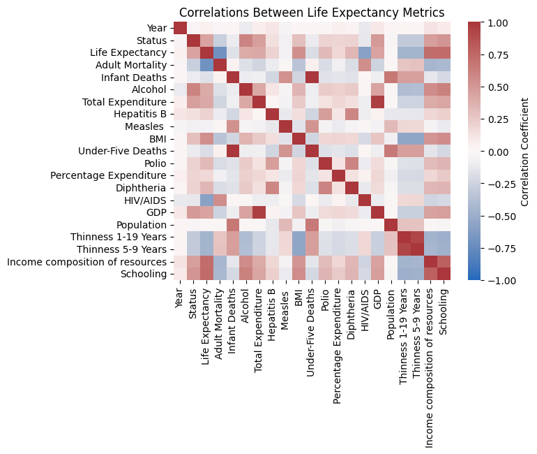

```python
# Plotting a heatmap of the correlation coefficient matrix
# Here, red tones indicate level of positive correlation,
# and blue tones indicate level of negative correlation
sea.heatmap(df_corr.corr(), vmin=-1.0, vmax = 1.0, cmap="vlag", cbar_kws={'label': 'Correlation Coefficient'})
plt.title("Correlations Between Life Expectancy Metrics")
plt.show()
```

#### Kruskal-Wallis Hypothesis Test

To decide how to explore what the dataset reveals about the role of immunization coverage on a population, we considered what else we were searching for in the data. Since we planned to both predict Life Expectancy based on financial factors, such as Total Expenditure and GDP, it made sense to consider how these factors are tied with immunization. Specifically, whether higher expenditure meant a larger immunization coverage across the country. Thus, the first hypothesis test we conducted explores the relationship between Total Expenditure and immunization coverage for Polio.

- $H_{0}$: The amount of total health expenditure in a country does not have an effect on the population's immunization coverage for polio.
- $H_{A}$: The amount of total health expenditure in a country has an effect on the population's immunization coverage for polio.

> Alpha Value is 0.05

When approaching this test, we wanted to categorize the total expenditure into ranges of spending. This was a more practical approach to communicating the results of the testing, as we wanted to be able to identify the effect of different brackets of health expenditure, rather than a singular value.

We at first wanted to conduct an ANOVA test, but as seen below, the mean spending is quite low in comparison to the range of possible values, with a very large standard deviation. This raised concern about whether the data was normally distributed. When plotted as a histogram, we can see that the data is extremely positively skewed, and thus does not meet the assumptions of normality required for an ANOVA test. Thus, we chose to conduct a Kruskal-Wallis Test instead.

```
Min Spending: 0.0 ; Max Spending: 18961.3486
Mean Spending: 698.9735580496973 ; Standard Deviation: 1759.2293363477404
```

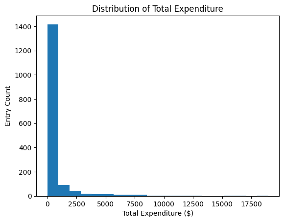

```python
print("Min Spending:", df['Total Expenditure'].min(), "; Max Spending:", df['Total Expenditure'].max())
print("Mean Spending:", df['Total Expenditure'].mean(), "; Standard Deviation:", df['Total Expenditure'].std())
plt.hist(df['Total Expenditure'], bins=20)
plt.xlabel('Total Expenditure ($)')
plt.ylabel('Entry Count')
plt.title('Distribution of Total Expenditure')
plt.show()
```

Given the maximum value of $18,961, the ranges we used were as follows:

**Low**: $0 - $5,000

**Mid**: $5,001 - $10,000

```python
def categorize(val):
  if val <= 5000:
    return 'Low'
  elif val <= 10000:
    return 'Mid'
  elif val <= 15000:
    return 'High'
  else:
    return 'Very High'

df_kruskal = pd.DataFrame(df)
df_kruskal['Bracket'] = df_kruskal['Total Expenditure'].apply(lambda x: categorize(x))
kruskal_ct = pd.crosstab(df_kruskal['Bracket'], df_kruskal['Polio'], rownames='B')
brackets = kruskal_ct.columns
pvalue = scipy.stats.kruskal(kruskal_ct[brackets].loc['Low'], kruskal_ct[brackets].loc['Mid'],
                           kruskal_ct[brackets].loc['High'], kruskal_ct[brackets].loc['Very High']).pvalue
print("P-Value: " + str(pvalue))
```

```
P-Value: 3.6410367835425685e-43
```

Since the P-value of $3.641 \times 10^{-43}$ is well below the alpha value of 0.05, there is an extremely low probability the null hypothesis is true. This suggests that the total health expenditure per capita of a country has an effect on its population's immunization coverage for polio.

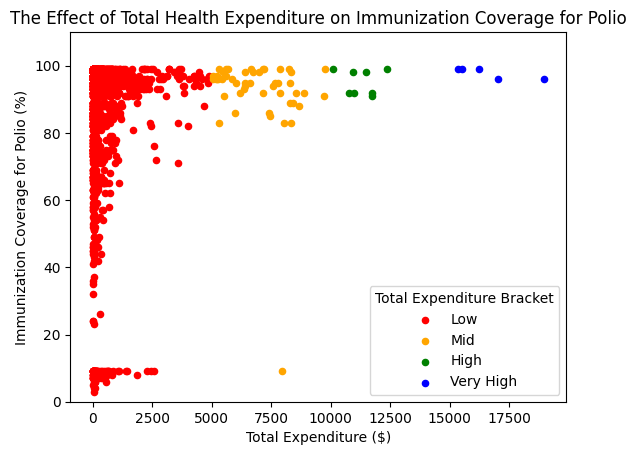

```python
# Represent the relationship with a scatter plot, while indicating how each
# expenditure bracket is categorized
low = df_kruskal[df_kruskal['Bracket'] == 'Low']
axis = low.plot(kind='scatter', x='Total Expenditure', y='Polio', color='red', label='Low')
mid = df_kruskal[df_kruskal['Bracket'] == 'Mid']
axis1 = mid.plot(kind='scatter', x='Total Expenditure', y='Polio', color='orange', label='Mid', ax=axis)
high = df_kruskal[df_kruskal['Bracket'] == 'High']
axis2 = high.plot(kind='scatter', x='Total Expenditure', y='Polio', color='green', label='High', ax=axis1)
vhigh = df_kruskal[df_kruskal['Bracket'] == 'Very High']
axis3 = vhigh.plot(kind='scatter', x='Total Expenditure', y='Polio', color='blue', label='Very High', ax=axis2)
axis.set_ylim(0, 110)
plt.legend(title='Total Expenditure Bracket')
plt.ylabel('Immunization Coverage for Polio (%)')
plt.xlabel('Total Expenditure ($)')
plt.title('The Effect of Total Health Expenditure on Immunization Coverage for Polio')
plt.show()
```

Taking note of the scatter plot as well, it is also important to note how sample size may be affecting the test's results. Even with the use of a non-parametric test like the Kruskal-Wallis test, it seems that the extreme skew of the data is still affecting the ability to determine a confident result. With the "Low" bracket being the largest, it appears that there is a wider range of values to account for than in other categories. It may be helpful to reconsider the criteria for each bracket, as well as evaluating immunization coverage for other diseases.

#### Line Graph - Exploring Life Expectancy Over Time

In this section, we explore the trend of life expectancy over time for both developed and developing countries. Through visualizing these two trends, we will be able to compare and uncover potential differences, patterns, trends. This will allow us to have an overall better understanding of how life expectancy evolved for both developed and developing countries before we proceed any further.

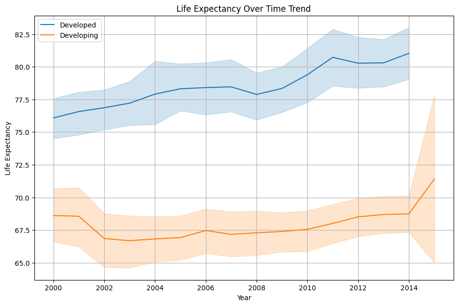

```python
developed = df[df['Status'] == 1]
developing = df[df['Status'] == 0]

plt.figure(figsize=(11, 7))
plt.title('Life Expectancy Over Time Trend')
sea.lineplot(x='Year', y='Life Expectancy', data=developed, label='Developed')
sea.lineplot(x='Year', y='Life Expectancy', data=developing, label='Developing')
plt.xlabel('Year')
plt.ylabel('Life Expectancy')
plt.legend()
plt.grid(True)
plt.show()
```

**Trends, Insights, Patterns, and Overall Analysis**

#### Mann-Whitney U Hypothesis Test

Beyond life expectancy we explore infant deaths and investigate whether there is any significant difference in infant deaths between developed and developing countries. This will further allow us to have a better understanding of there truly is a disparity between developed and developing countries and if there might be underlying factors worth exploring.

- $H_{0}$ (Null Hypothesis): There is no difference in infant deaths between developed and developing countries (infant deaths are the same).
- $H_{A}$ (Alternative Hypothesis): There is a difference in infant deaths between developed and developing countries.

> Alpha Value is 0.05

```python
# creating the respective data frames
developing = df[df['Status'] == 0]['Infant Deaths']
developed = df[df['Status'] == 1]['Infant Deaths']

# checking out the data
print(developing.describe())
print(developed.describe())
```

```
count    1407.000000
mean       38.002132
std       130.057737
min         0.000000
25%         1.000000
50%         6.000000
75%        27.500000
max      1600.000000
Name: Infant Deaths, dtype: float64
count    242.000000
mean       0.871901
std        1.079859
min        0.000000
25%        0.000000
50%        0.000000
75%        2.000000
max        4.000000
Name: Infant Deaths, dtype: float64
```

```python
alpha = 0.05
statistic, p_value = scipy.stats.mannwhitneyu(developed, developing)

print(f'Mann-Whitney U Test Statistic: {statistic:.3f}')
print(f'P-value: {p_value}')

if p_value < alpha:
    print("Since the p_value is less than alpha we reject the null hypothesis that there is no significant difference in infant deaths between developed and developing countries.")
else:
    print("Since the p_value is greater than alpha we fail to reject the null hypothesis that there is no significant difference in infant deaths between developed and developing countries.")
```

```
Mann-Whitney U Test Statistic: 69452.500
P-value: 6.156890810747787e-50
Since the p_value is less than alpha we reject the null hypothesis that there is no significant difference in infant deaths between developed and developing countries.
```

##### Plot

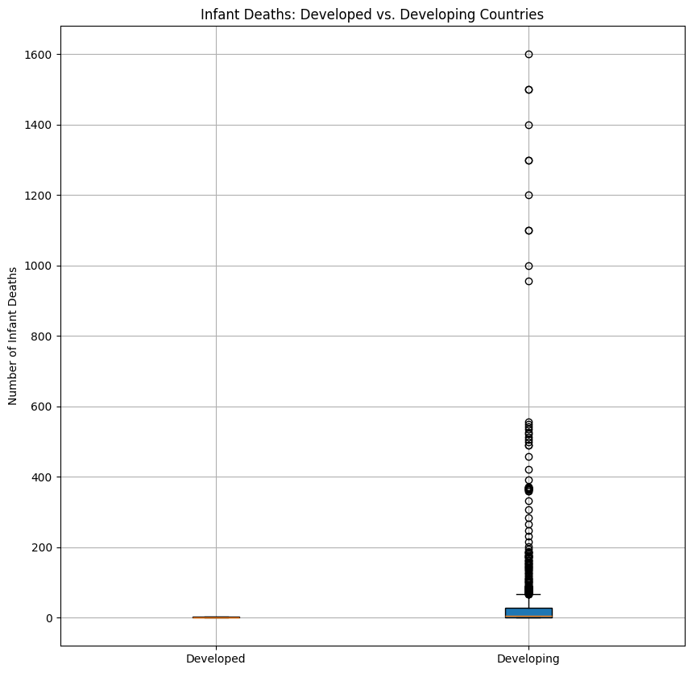

```python
infant_death_data = [developed, developing]
plt.figure(figsize=(10, 10))
plt.boxplot(infant_death_data, labels=['Developed', 'Developing'], patch_artist=True)
plt.title('Infant Deaths: Developed vs. Developing Countries')
plt.ylabel('Number of Infant Deaths')
plt.grid(True)
plt.show()
```

##### Conclusion

> The p-value is 6.16e-50 which is below our alpha (0.05), therefore we reject the null hypothesis. Which suggests that there is a significant difference between developed and developing countries in terms of infant deaths.

## 4. Primary Analysis

#### Predicting Life Expectancy Using Average Years of Schooling

Since the correlation coefficient matrix calculated suggested a high positive correlation between Life Expectancy and Schooling, we decided to build a model that would predict Life Expectancy based on the average number of years of schooling. The World Health Organization (WHO) discusses the importance of [female education levels](https://https://www.who.int/data/nutrition/nlis/info/female-education-levels) as a factor impacting life expectancy and quality of life. While our dataset is not able to specify by gender, we found various other studies exploring the impact of schooling on life expectancy, and wanted to explore the general relationship in this dataset. Given our exploration in other sections about financial impact on life expectancy and health, schooling was another relevant factor to explore.

We started by creating a linear regression model as a baseline for determining an accurate model for prediction.

```python
from sklearn.linear_model import LinearRegression, LogisticRegression
from sklearn.model_selection import train_test_split
from sklearn.preprocessing import PolynomialFeatures
from sklearn.pipeline import make_pipeline
from sklearn.metrics import mean_squared_error, r2_score
from sklearn.linear_model import ElasticNet
import math

seed = 24

# Splitting into training and test sets to help determine model accuracy later
split_df = train_test_split(df, test_size=0.3, random_state=seed)

X_disease_train = split_df[0][['Schooling']]
X_disease_test = split_df[1][['Schooling']]
y_disease_train = split_df[0][['Life Expectancy']]
y_disease_test = split_df[1][['Life Expectancy']]

model_disease = LinearRegression().fit(X_disease_train, y_disease_train)
y_disease_pred = pd.DataFrame(model_disease.predict(X_disease_test))

# Calculate Mean Squared Error and R-Squared Value to observe model accuracy
mse = mean_squared_error(y_disease_test, y_disease_pred)
r2 = r2_score(y_disease_test, y_disease_pred)

print("Root Mean Squared Error: " + str(math.sqrt(mse)) + " R-Squared Value: " + str(r2))
```

```
Root Mean Squared Error: 5.729241815784378 R-Squared Value: 0.5651642065036828
```

After training the model with a portion of the data, we then used a separate portion to test its ability to accurately predict Life Expectancy based on the given average number of Schooling. When comparing these predicted values to the actual values, we can see that there is an root mean squared error of about 5.729. This means that the model's prediction for Life Expectancy deviates from the true values by about 5.729 years on average. The R-Squared value also reflects the model's moderate ability to make accurate predictions, since at 0.565 it is closer to 1, than 0. This indicates a moderate ability to account for the variance present in the dataset.

Given that there was room for the unaltered linear regression model to better predict values, we then treated the relationship between Life Expectancy and Schooling as non-linear. Thus, for our next version of the regression model, we first transformed the data so that the relationship between variables would be linear before being fed into the linear regression model. For this transformation, we chose a degree of 4, in order to accommodate the non-linear relationship without overfitting to the training data. A larger degree would allow the regression line to match the relationship more closely; however, it also would run the risk of being so attune to the training data that it is unable to predict values for new, unfamiliar data.

```python
model_disease_poly = make_pipeline(PolynomialFeatures(4), LinearRegression()).fit(X_disease_train, y_disease_train)
y_disease_poly_pred = pd.DataFrame(model_disease_poly.predict(X_disease_test))

mse = mean_squared_error(y_disease_test, y_disease_poly_pred)
r2 = r2_score(y_disease_test, y_disease_poly_pred)

print("Root Mean Squared Error: " + str(math.sqrt(mse)) + " R-Squared Value: " + str(r2))
```

```
Root Mean Squared Error: 5.566757834379124 R-Squared Value: 0.5894787545959688
```

Here, we can see marginal improvement. The root mean squared error decreased by about .16, while the R-Squared value increased by about .02. While both these changes show improvement, it is not large enough to argue that the polynomial regression is an improvement from the linear regression model. Since the correlation coefficient was about .728, this value indicates a rather high positive correlation. The data types for both Life Expectancy and Schooling are continuous, raising the question of what might be a preferable method than Linear Regression to model and predict the relationship between these two variables. It may be necessary to consider a different method, or continue to transform or regularize the data to form an improved model.

#### Predicting Life Expectancy Based On Economics (Income Composition of Resources)

Based on the exploratory section, we have seen a high correlation between life expectancy and income composition of resouces through the heatmap in the correlation coefficient matrix. Furthermore, through the analysis of historical trends of life expectancy, we uncovered the differences between developed and developing countries and that high life expectancies in developed countries could potentially translate to economic factors. Therefore, here we are creating a linear regression model due to the quantitative nature of the data and predicting life expectancy based on Income Composition of Resources.

```python
import numpy as np
from sklearn.model_selection import train_test_split
from sklearn.linear_model import LinearRegression
from sklearn.metrics import r2_score
from sklearn.metrics import mean_squared_error

# Defining X and y
X_econ = df[['Income composition of resources']]  # Independent variable
y_econ = df['Life Expectancy']  # Dependent variable

random_state = 42
np.random.seed(random_state)

# Splitting the data into training and testing sets
X_econ_train, X_econ_test, y_econ_train, y_econ_test = train_test_split(X_econ, y_econ, random_state=42)


# Creating a Linear Regression model
model_econ = LinearRegression()

# Fit the model
model_econ.fit(X_econ_train, y_econ_train)

# predicting
y_econ_pred = model_econ.predict(X_econ_test)

# Evaluation of the model
mse = mean_squared_error(y_econ_test, y_econ_pred)
r2 = r2_score(y_econ_test, y_econ_pred)

print("Mean Squared Error:", mse)
print("R-Squared Value:", r2)
```

```
Mean Squared Error: 30.12199627870841
R-Squared Value: 0.5973405107278367
```

Through the evaluation of the model, we see that our model is a moderate (leaning on the stronger side) fit to the data. This is because the R^2 coeffcient is approximately 0.597 which is in between 0 and 1 but leaning more to 1. And as we know the closer the coefficient is to a 1, the model cpatures more of the variance/complexities in the data. Also, we know there's some error (average squared difference between predicted and actual values) and the closer it is to 0 the better here.

It would be beneficial to explore the possibility that there is a non linear relationship within the data. In this case, it would be better to use polynomial features to transform the assumed non linear relationship into a linear one. This could allow for an effective application of linear regression. Reasoning behind this is because the R^2 coefficient is not exactly super close to 1 and getting a lower MSE value would indicate less error.

```python
from sklearn.linear_model import LinearRegression
from sklearn.preprocessing import PolynomialFeatures
from sklearn.pipeline import make_pipeline
from sklearn.metrics import r2_score
from sklearn.metrics import mean_squared_error

degree = 3

# Creating a pipeline with Polynomial Regression
econ_poly = PolynomialFeatures(degree=2)

model_econ_poly = make_pipeline(econ_poly, LinearRegression())

# fit
model_econ_poly.fit(X_econ_train, y_econ_train)

# predict
y_econ_pred_poly = model_econ_poly.predict(X_econ_test)

# Evaluation of the model
test_r2 = r2_score(y_econ_test, y_econ_pred_poly)
mse = mean_squared_error(y_econ_test, y_econ_pred_poly)
print(f'Test MSE (Polynomial Regression): {mse}')
print(f'Test R-squared (Polynomial Regression): {test_r2}')
```

```
Test MSE (Polynomial Regression): 23.034189564118908
Test R-squared (Polynomial Regression): 0.6920876385526196
```

Compared to our previous linear regression model, we see a significant improvement in our Polynomial Regression one through both the MSE and R^2 coefficient. As we see our MSE has decreased from 30 to 23 approximately indicating less error overall. Also our R^2 has increased and is closer to 1. This indicates a better capture of variance and better fit of model to the data.

## 5. Visualization

#### Visualizing Life Expectancy Predictions Against Average Years of Schooling

Part of our evaluation of the Linear Regression model used to predict Life Expectancy from average years of Schooling was plotting the data against the regression line. Below, we visualize the first purely linear regression line predictions against the actual data.

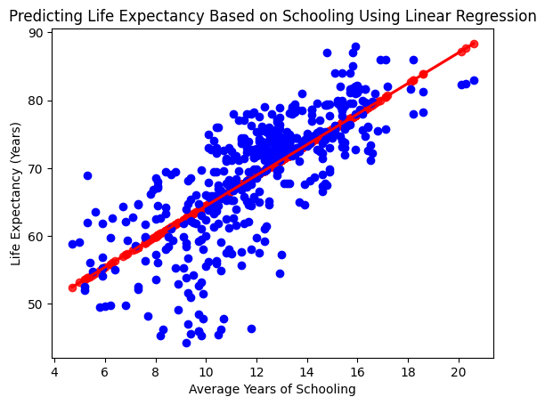

```python
sea.regplot(x=X_disease_test, y=y_disease_pred, order=4, color='red')
plt.scatter(X_disease_test, y_disease_test, color='blue')
plt.title('Predicting Life Expectancy Based on Schooling Using Linear Regression')
plt.xlabel('Average Years of Schooling')
plt.ylabel('Life Expectancy (Years)')
plt.show()
```

Visually, it is clear that the line passes almost directly through the center of the data. However, the range of error is especially evident with lower values for years of schooling, since there appears to be the greatest variation of Life Expectancy for 6-12 years of schooling.

After creating the linear regression model with polynomial features, we again plotted the regression line against the actual test data, as shown below.

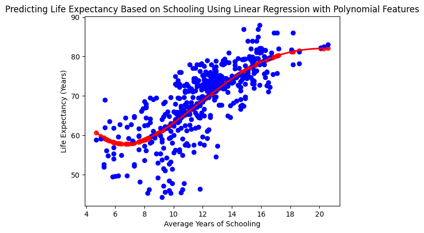

```python
sea.regplot(x=X_disease_test, y=y_disease_poly_pred, order=4, color='red')
plt.scatter(X_disease_test, y_disease_test, color='blue')
plt.title('Predicting Life Expectancy Based on Schooling Using Linear Regression with Polynomial Features')
plt.xlabel('Average Years of Schooling')
plt.ylabel('Life Expectancy (Years)')
plt.show()
```

Here, we can see that the model similarly is unable to represent the variation of the data at the 6 to 12 year range for average years of schooling. With these visualizations, we can better understand the limitations of the model, and why there was little improvement between the two. It can be reasoned that the model is able to more accurately predict Life Expectancy for higher average years of schooling, than lower ones. However, this also brings into question what other variables are affecting both of these features. The high level of variation for Life Expectancy for countries with an average of 6 to 12 years of schooling may be explainable by other factors, thus meaning that our model as it stands is not able to fully represent the expanse of this relationship.

#### Visualizing Life Expectancy Based On Economics (Income Composition of Resources)

Now let's visualize our polynomial regression model for predicting life expectancy based on ecnomics (income composition of resources).

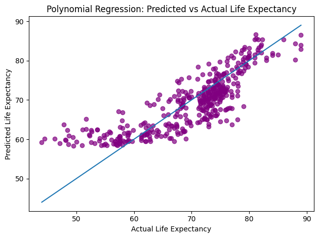

```python
import matplotlib.pyplot as plt

plt.scatter(y_econ_test, y_econ_pred_poly, color='purple', alpha=0.7)
plt.plot([min(y_econ_test), max(y_econ_test)], [min(y_econ_test), max(y_econ_test)])
plt.title('Polynomial Regression: Predicted vs Actual Life Expectancy')
plt.xlabel('Actual Life Expectancy')
plt.ylabel('Predicted Life Expectancy')
plt.tight_layout()
plt.show()
```

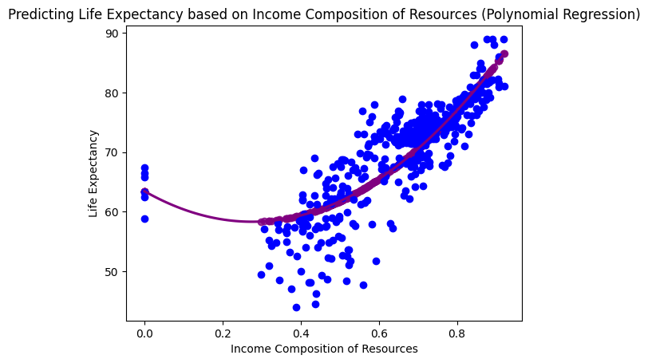

```python
import matplotlib.pyplot as plt
import seaborn as sns

sns.regplot(x=X_econ_test, y= y_econ_pred_poly, order = 3, color='purple')
plt.scatter(X_econ_test, y_econ_test, color='blue')
plt.title('Predicting Life Expectancy based on Income Composition of Resources (Polynomial Regression)')
plt.xlabel('Income Composition of Resources')
plt.ylabel('Life Expectancy')
plt.show()
```

Visualization Analysis: As seen through the first plot in this section (Polynomial Regression: Predicted vs Actual Life Expectancy) there is overall a positive linear correlation which indicates that our model does indeed perform well (model accuracy check). Then through our second visualization (Predicting Life Expectancy based on Income Composition of Resources (Polynomial Regression)) we are able to see what the model actually predicts given income composition of resources data. As we can see, the line fits fairly well to the to the data, only problem maybe due the lack of data available for income of composition from 0 to 0.3. Due to this gap, we are unable to verify if the model works well for this portion of it. Also from 0.4 to 0.6 the line tends to capture the complexities of the data fully as it leans higher in life expectancy in comparison to other parts of the data.

## 6. Insights and Conclusion

After progressing through this project, it is clear that there is much more to be explored in the realm of relationships between Life Expectancy and different health statistics for a country's public health. We were able to scratch the surface regarding potential influences, such as average years of schooling for a population. While we separately delved into how a year's worth of health expenditure may affect a country's immunization coverage for a disease within said year, further exploration would benefit from taking one step further to factoring in life expectancy.

The results of our linear regression model continued to indicate the potential for how interconnected the features of this dataset may be. Despite the moderately high positive correlation between schooling and life expectancy, there was still a significant margin of error in being able to accurately predict life expectancy. In a broader context, we can understand how difficult it may be to pinpoint exact solutions to issues of health disparity within a population. By using life expectancy as a representative of this disparity, we were able to learn the obstacles in adequately addressing precise influences and what changes may create positive change to increase life expectancy.

An unfamiliar reader would be able to use this project to ease into the complexities of identifying relationships between variables relating to a country's health. Throughout the process of exploration and analysis, we are able to take different avenues into addressing this issue. While there was a lot of trial and error, we discovered the potential for important relationships and were able to identify areas a more detailed project would be able to address. As the [UN's 2022 Policy Brief](https://www.un.org/development/desa/dpad/publication/un-desa-policy-brief-no-145-on-the-importance-of-monitoring-inequality-in-life-expectancy/) on inequalities in life expectancy states, "countries do not systematically monitor inequalities in life expectancy, suggesting that their importance is still unknown or less understood by policymakers". This demonstrates the room for exploration in this topic and the importance of exploring various possible relationships.

An important takeaway from this project as seen through exploring historical life expectancy trends, infant mortality for developed vs. developing countries, correlation between economic factors and life expectancy, and the model which predicted life expectancy based on economic factors. It is clear that there is a huge disparity when it comes to developed and developing countries. Generally, developed countries tend to enjoy a higher life expectancies due to various economic advantages.This calls for a crucial need in economic resources in these developing countries so that they can achieve high life expectancies as well and overall better health.